## Violin plots

Violin plots show the distribution of a continuous variable. They are similar to boxplots, but also show the density plots. While a boxplot shows only summary statistics, a violin plot shows the full distribution of the data. This is useful if the data is **multi-modal**. They are useful for comparing distributions between different groups. In ggplot2, the `geom_violin()` function is used to produce violin plots. The data used in the examples comes from the `{palmerpenguins}` package.

### A simple violin plot

The simplest violin plot will look at the distribution of `bill_length_mm` across all types of penguins. Unlike `geom_boxplot()`, `geom_violin()` does not work without specifying both `x` and `y` in the `aes()` function. So, to generate a violin plot for a single variable, we set the `x` (or `y` variable to a fixed value). You can set it to any value you want, here 1 is used.

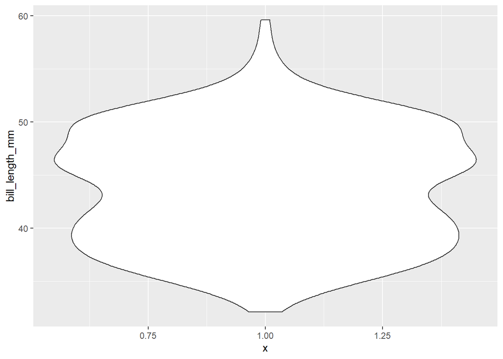

```r
ggplot(data = penguins,
       mapping = aes(x = 1,
                     y = bill_length_mm)) +
  geom_violin()
```

### Multiple categories

The distribution of multiple (discrete) categories can be visualised by setting the `x` (or `y` if horizontal violin are desired).

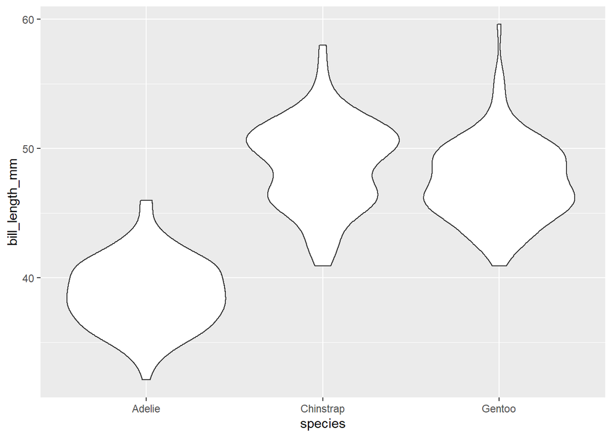

```r
ggplot(data = penguins,
       mapping = aes(x = species,
                     y = bill_length_mm)) +
  geom_violin()
```

### Adding colour

There are two ways to add colour to violin plots: (i) using `colour` (or `color`) which changes the colour of the outline of violin plots; (ii) using `fill` which changes the colour of the inner area of the violin plots. If `colour` or `fill` is set outside the `aes()` function, it must be a valid colour name, and will set the same colour for all violin plots. If `colour` or `fill` is set inside the `aes()` function, the colours will change based on the value of a variable. Here, the `fill` is set to `"blue"` for all categories.

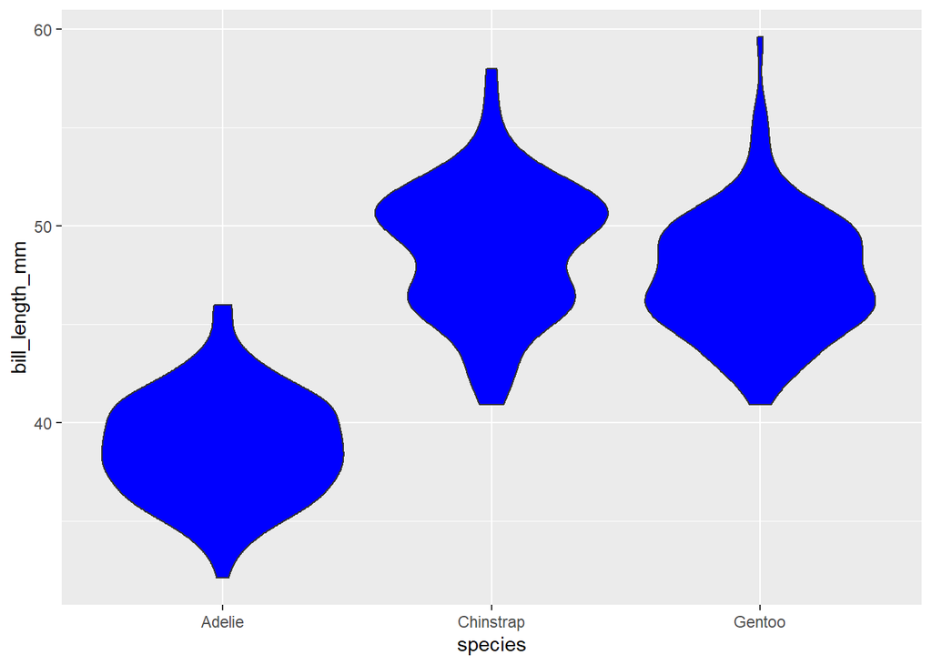

```r
ggplot(data = penguins,
       mapping = aes(x = species,
                     y = bill_length_mm)) +
  geom_violin(fill = "blue")
```

### Final version

Since the colours change in the same way as the values on the x-axis, a legend is not needed in this plot. The legend can be hidden using `theme(legend.position = "none")`. A title, subtitle, caption, and axis titles are set through the `labs()` function. The built-in minimalist {ggplot2} theme is added in here using `theme_minimal()`.

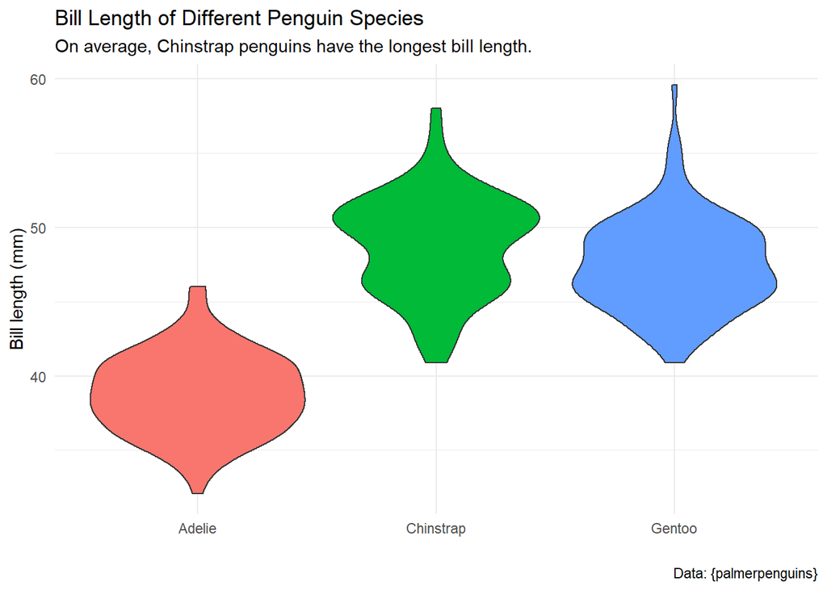

```r
ggplot(data = penguins,
       mapping = aes(x = species,
                     y = bill_length_mm,
                     fill = species)) +
  geom_violin() +
  theme_minimal() +
  labs(title = "Bill Length of Different Penguin Species",
       subtitle = "On average, Chinstrap penguins have the longest bill length.",
       caption = "Data: {palmerpenguins}",
       x = "",
       y = "Bill length (mm)") +
  theme(legend.position = "none")
```